# SCUBIDO

**S**imulating **C**limate **U**sing **B**ayesian **I**nference from proxy **D**ata **O**bservations

[figure not shown]

This vignette is used to explain in greater detail the work flow of the `SCUBIDO` R package.

The aim of this package is to create a reconstruction of palaeoclimate given multivariate μXRF-CS data from lake sediments using Bayesian inference. More detaols on the mathematics behind the model can be found in Boyall et al (in prep).

It is vital that each of the **3** functions are used for this package otherwise the package will fail. Therefore this vignette walks you each function.

### Introduction

The first thing to do it load in the `SCUBIDO` package. If `SCUBIDO` is not already installed then do so by loading the `devtools` package and then installing from Github.

```r
devtools::install_github("LauraBoyall/SCUBIDO") # if not previously installed
library(SCUBIDO)
```

## Loading in your data

The `SCUBIDO` package requires two datasets, the first being some modern data `modern_data` with the most recent part of the μXRF-CS data which has an overlap with some instrumental climate data. For example it may be a section from 1950 to present. It is important for this data set that the age (**in cal BP**) is in the first column, the climate data is in the second and then the remaining columns are the individual elements. We recommend here that your μXRF-CS data is central-log ratio transformed.

An example of the structure data set is displayed below using a fake data set:

```
#>  Age_BP Temperature_Anomaly   S  Si   K  Ca  Ti   M   V  Rb  Sr
#>     -40         -0.28023782 239 785 986 354 237 845 471 924 274
#>     -39         -0.11508874 962   9 137 366 686 260 366 543 594
#>     -38          0.77935416 601 779 905 287 226  23 121 852 160
#>     -37          0.03525420 515 729 576  80 318 862  47 584 853
#>     -36          0.06464387 403 630 395 365 174 335 263 668 848
#>     -35          0.85753249 880 481 450 178 801 632 969 511 478
```

The second data set required is the `fossil_data`. This data is the remainder of your μXRF-CS data and follows the same structure as the modern but the second column which held the climate value is not there. Therefore you should have one less column in your table. Example below:

```
#>    Age_BP   S  Si   K  Ca  Ti   M   V  Rb  Sr
#>  291.3588 600 239 785 986 354 237 845 471 924
#>  292.1683 333 962   9 137 366 686 260 366 543
#>  292.6364 489 601 779 905 287 226  23 121 852
#>  293.5311 954 515 729 576  80 318 862  47 584
#>  294.4775 483 403 630 395 365 174 335 263 668
#>  294.6185 890 880 481 450 178 801 632 969 511
```

Once the data is set up we can begin by using the `SCUBIDO` package!

## SCUBIDO_input

The `SCUBDIO_input` function is used to sort your data and split create a data list to be used later in the model. It is important that you save the outputs of the function as shown below as these are needed in the following function.

the summary print out shows what is saved within the sorted list. This function also re-scales the μXRF-CS data and creates a few time files which help with later application.

```r
sorted_data <- SCUBIDO_input(modern_data = modern_data, fossil_data = fossil_data)
summary(sorted_data)
```

```
#>            Length Class  Mode
#> time_m       75   -none- numeric
#> temp_m       75   -none- numeric
#> xrf_m_resc  975   -none- numeric
#> time_f      570   -none- numeric
#> xrf_f      7410   -none- numeric
#> xrf_f_resc 7410   -none- numeric
#> time_grid  2183   -none- numeric
#> time_fm     645   -none- numeric
#> time_all   2750   -none- numeric
```

## SCUBIDO_cal

Once the data has been sorted we can now begin to model the data! This first function involves the calibration modern data. Within this stage we learn about the relationship between the individual elements and climate, but also about the covariance between them.

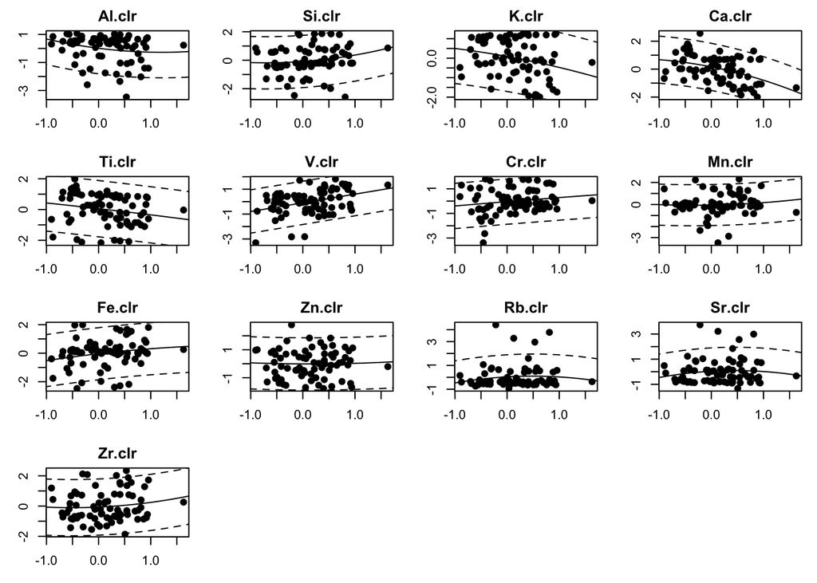

```r
calibrated_data <- SCUBIDO_cal(sorted = sorted_data, plot = TRUE, summary = FALSE)
```

If you choose to also do `plot = TRUE` then you will get a series of graphs showing the quadratic relationship between the XRF elements and the climate time series. All of the outputs for this will be stored in your calibrated file, for our example it will be stored in `calibrated_data` and the `sims.list` list stored inside this will have all of the model outputs if you would like to plot differently / explore the model and then the `sorted` list stored in the `calibrated_data` contains the data from the previous function.

## SCUBIDO_reconstruct

The final function in SCUBIDO is `SCUBIDO_reconstruct` and this will produce the final reconstruction of quantitative climate given μXRF-CS data. Like usual we we load in the previous function’s file (`calibrated_data`).

**Note that this function does take a long time, it will ask you if you wish to continue but please be aware that for thousands of date layers (rows in your xrf data) then it is possible that it could take up to 24 hours (why not run it over the weekend!). This is based on running it on a single core so if you can use parallel cores then use this.**

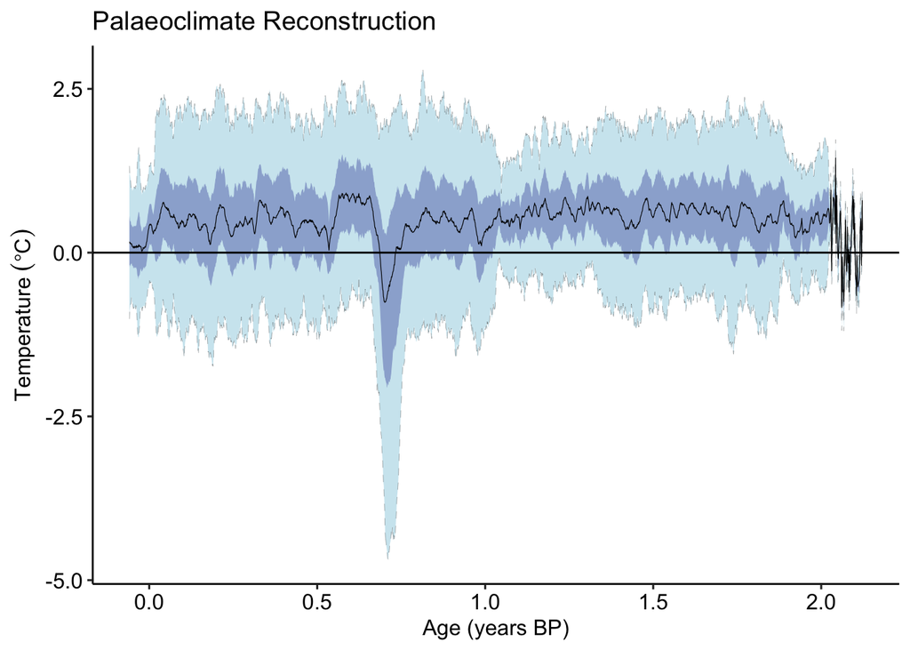

```r
reconstruction <- SCUBIDO_reconstruct(calibration_data = calibrated_data, plot_graph = TRUE)
```

Whilst this is the default plot the function produces, you can easily extract the resulting data frame and plot in whichever way you wish.

```r
final <- reconstruction$reconstruction # note that we have saved our reconstruction as 'reconstruction' however you may have chosen a different name!

# write.csv(final, "Final Climate Reconstruction.csv)
```

And there you have it! By this point you would have been able to reconstruct annual climate given μXRF-CS data! If you have any queries please contact Laura Boyall at Laura.boyall.2016@live.rhul.ac.uk

You must cite the original publication (Boyall et al., in prep) if you use this package to publish any work.

*Happy modelling!!*